# A point on the nonparametric maximum likelihood estimation (NPMLE) of the empirical cumulative distribution function (ECDF) for censored data

Marie Laure Delignette-Muller

21 juillet 2017

# NPMLE : a difficult problem

In the current version of our package, the empirical cumulative distribution function (ECDF) is estimated using the Turnbull algorithm as implemented in the survival package. This estimation was shown to be problematic (see Gentleman and Geyer 1994, Fay 2010, …) and indeed is not directly usable to build PP plots or QQ plots. In nonparametric maximum likelihood estimation (NPMLE) algorithms, the firts step is the definition of the set of disjoint intervals (some with null width) under which the ECDF may change : this set is called the **maximal intersection intervals** (Wang 2008) or the maximal cliques of the data (Liu 2011) or the equivalence classes (Guolin 2008) or the Turnbull intervals or the innermost intervals (Fay 2010). These maximal intersection intervals are defined by each left bounds immediately followed by a right bounds once the bounds are ordered. Interval of null width correspond to values of non censored data or to a left bound exactly at the same value of a rigth bound.

To understand this definition let us take a simple example with left, right, interval censored data and non censored data. In the following we can visualize the bounds as a black plain line for left bound and a green dotted line for right bound (non censored data coded with the same value for left and right bound were plotted in pink plain lines) added at the Turnbull plot provided in the survival package.

```r
d1 <- data.frame(left = c(1, 2, 3, 4, 3, 7), right = c(2, 5, 3, 7, 8, 9))
d <- d1
(survdata <- Surv(time = d$left, time2 = d$right, type="interval2"))
```

```
## [1] [1, 2] [2, 5] 3      [4, 7] [3, 8] [7, 9]
```

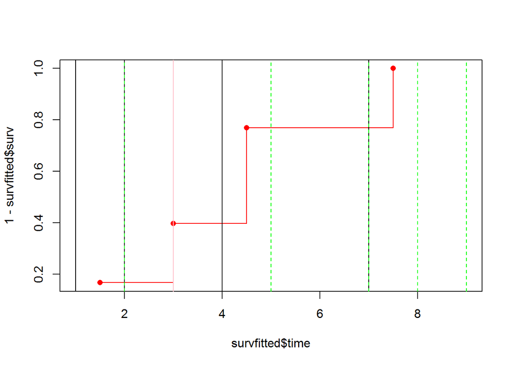

```r
survfitted <- survfit(Surv(left, right, type="interval2") ~ 1, data = d)
plot(survfitted$time, 1- survfitted$surv, type = "s", col = "red", xlim = c(min(d$left), max(d$right)))
points(survfitted$time, 1 - survfitted$surv, col = "red", pch = 16)
abline(v = d$left, col = "black")
abline(v = d$right, col = "green", lty = 2)
noncensored <- d$left[d$left == d$right]
abline(v = noncensored, col = "pink")
```

The second step of an NPMLE algorithm aims at estimating the **mass of each maximal intersection interval**. Many algorithms were proposed for this purpose and it seems to be a tricky problem. The result of the algorithm is thus a list of **maximal intersection intervals with their corresponding mass** from which it i easy to compute an ECDF. The Turnbull algorithm implemented in the survival package does not provide the intervals but only the survival function at each mid-point of an interval. Latest algorithms provided in R packages Icens, interval and npsurv provide the intervals and propose to represent by rectangles the areas where the function (survival or ECDF) is not unique. This type of representation (representational non-uniqueness) was introduced by Gentleman and Vandal (2002). Let us compare the representation provided by the survival package (red line) and the one provided by the Icens package for the Turnbull algorithm on the previous example.

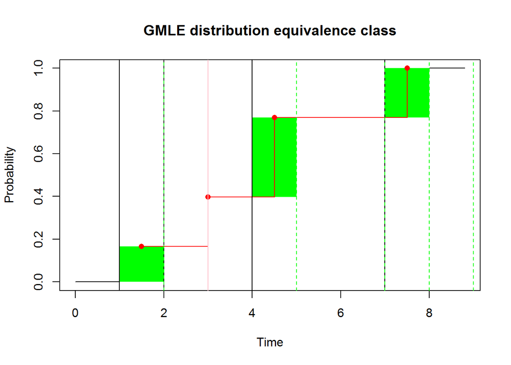

```r
fit <- EM(d)
plot(fit)
lines(survfitted$time, 1- survfitted$surv, type = "s", col = "red", xlim = c(min(d$left), max(d$right)))
points(survfitted$time, 1 - survfitted$surv, col = "red", pch = 16)
abline(v = d$left, col = "black")
abline(v = d$right, col = "green", lty = 2)
noncensored <- d$left[d$left == d$right]
abline(v = noncensored, col = "pink")
```

The package interval gives the same type of representation with a linear interpolation within each rectangle but only as a survival curve (it is not possible to plot it directly in ECDF).

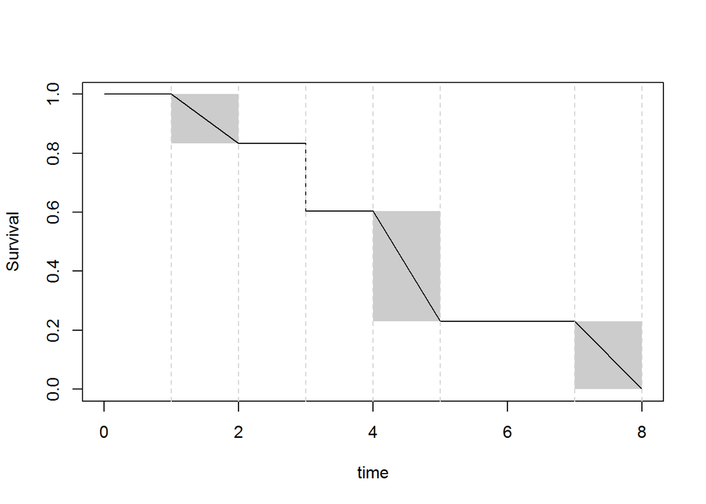

```r
fit <- icfit(Surv(left, right, type ="interval2") ~ 1, data = d)
plot(fit)
abline(v = d$left, col = "lightgrey", lty = 2)
abline(v = d$right, col = "lightgrey", lty = 2)
```

The package npsurv also gives the same type of representation in survival plot with different options of plot.

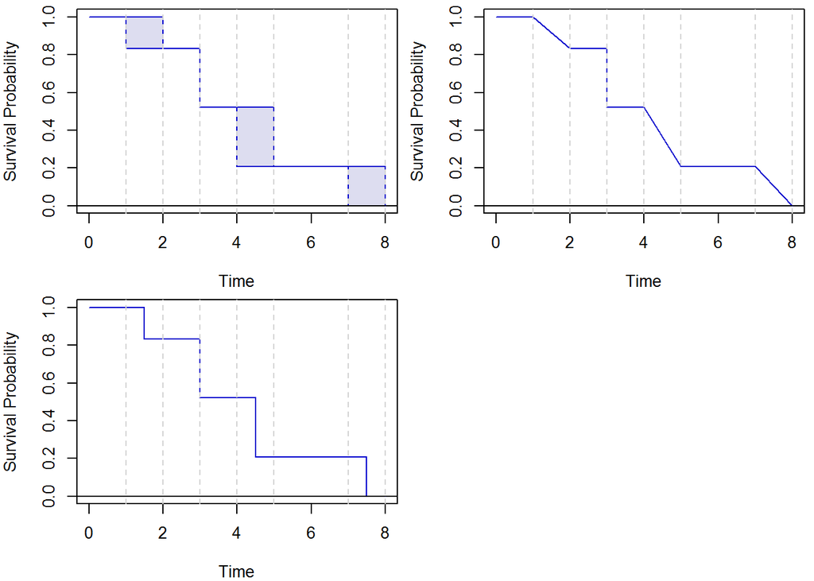

```r
par(mfrow = c(2, 2))
par(mar = c(4,4,0.5,0.5))
f <- npsurv(d, verb = 0)$f
plot(f, style = "box")
abline(v = d$left, col = "lightgrey", lty = 2)
abline(v = d$right, col = "lightgrey", lty = 2)
plot(f, style = "uniform")
abline(v = d$left, col = "lightgrey", lty = 2)
abline(v = d$right, col = "lightgrey", lty = 2)
plot(f, style = "midpoint")
abline(v = d$left, col = "lightgrey", lty = 2)
abline(v = d$right, col = "lightgrey", lty = 2)
```

The different algorithms differ in their estimation of the mass corresponding to each maximal intersection interval. To visualize that we will use the following function on different data sets.

```r
compareNPMLE <- function(d)
{
  # d is a data set with censored values coded by NA as in fitdistrplus
  ## transformation of NA in -Inf or Inf necessary for other packages than survival
  db <- d
  db$left[is.na(db$left)] <- -Inf
  db$right[is.na(db$right)] <- Inf

  e1 <- VEM(db) # A Vertex-exchange-method in $D$-optimal Design Theory , D. Bohning, Metrika, 1986.
  e1$numiter
  # trial to analyse the difference with d1
  e1bis <- VEM(db, tol = 1e-10, tolbis = 1e-10) # A Vertex-exchange-method in $D$-optimal Design Theory , D. Bohning, Metrika, 1986.
  e1bis$numiter

  # plot(e1)
  e2 <- EM(db) # Turnbull 1976
  # plot(e2)
  e3 <- PGM(db) # Some Algorithmic Aspects of the Theory of Optimal Designs, C.-F. Wu, 1978, Annals.
  # plot(e3)
  e4 <- EMICM(db) # A hybrid algorithm for computation of the nonparametric maximum likelihood
  # estimator from censored data, J. A. Wellner and Y. Zhan, 1997, JASA.
  # plot(e4)
  #e5 <- ISDM(db) # An Algorithm for Computing the Nonparametric MLE of a Mixing Distribution,
  # Lesperance, Mary L. and Kalbfleisch, John D., JASA, 1992
  # plot(e5)
  # Methode trop lente sur les gros jeux de donnes !!!!!!!!!!!!!!!!!!!!

  mass.Icens.VEM <- e1$pf
  mass.Icens.EM <- e2$pf
  mass.Icens.PGM <- e3$pf
  mass.Icens.EMICM <- e4$pf
  #mass.Icens.ISDM <- e5$pf

  # pour avoir les bornes des intervalles d'equivalence
  # e1$intmap

  # comparatif avec algo de npsurv
  f <- npsurv(db, verb = 0)$f
  mass.npsurv <- f$p
  # pour avoir les bornes des intervalles d'equivalence
  # rbind(f$left, f$right)

  # npsurv(db, verb = 0, tol = 1e-10)$numiter
  # npsurv(db, verb = 0, tol = 1e-12)$f

  # comparatif avec Turnbull de survival
  survdata <- Surv(time = d$left, time2 = d$right, type="interval2")
  survfitted <- survfit(Surv(left, right, type="interval2") ~ 1, data = d)
  s <- survfitted$surv
  ns <- length(s)
  savant <- c(1, s[-ns])
  mass.survival <- savant - s

  # comparatif avec icfit
  fit <- icfit(Surv(left, right, type ="interval2") ~ 1, data = db)
  mass.interval <- fit$pf
  names(mass.interval) <- NULL


  print("mass.Icens.VEM")
  print(mass.Icens.VEM)
  print("mass.Icens.EM")
  print(mass.Icens.EM)
  print("mass.Icens.PGM")
  print(mass.Icens.PGM)
  print("mass.Icens.EMICM")
  print(mass.Icens.EMICM)
#  mass.Icens.ISDM
  print("mass.survival")
  print(mass.survival)
  print("mass.interval")
  print(mass.interval)
  print("message of icfit concerning Kuhn-Tucker conditions")
  print(fit$message)
  print("mass.npsurv")
  print(mass.npsurv)

  par(mfrow = c(2,2))
  par(mar = c(4,4,0.5,0.5))
  plot(e1, surv = TRUE, main = "")
#  points(survfitted$time, survfitted$surv, col = "red", pch = 16)
  lines(survfitted$time, survfitted$surv, type = "s", col = "red", lty = 2)
  legend("bottomleft", legend = "VEM(Icens) in green and survival in red", bty = "n")

  plot(f)
#  points(survfitted$time, survfitted$surv, col = "red", pch = 16)
  lines(survfitted$time, survfitted$surv, type = "s", col = "red", lty = 2)
  legend("bottomleft", legend = "npsurv in blue and survival in red", bty = "n")

  plot(fit)
#  points(survfitted$time, survfitted$surv, col = "red", pch = 16)
  lines(survfitted$time, survfitted$surv, type = "s", col = "red", lty = 2)
  legend("bottomleft", legend = "interval in grey and survival in red", bty = "n")
}
```

Let us use this function on the previous example :

```r
compareNPMLE(d)
```

```
## [1] "mass.Icens.VEM"
## [1] 0.167 0.230 0.373 0.230
## [1] "mass.Icens.EM"
## [1] 0.167 0.230 0.373 0.230
## [1] "mass.Icens.PGM"
## [1] 0.167 0.230 0.373 0.230
## [1] "mass.Icens.EMICM"
## [1] 0.167 0.230 0.373 0.230
## [1] "mass.survival"
## [1] 0.167 0.230 0.373 0.230
## [1] "mass.interval"
## [1] 0.167 0.230 0.373 0.230
## [1] "message of icfit concerning Kuhn-Tucker conditions"
## [1] "normal convergence"
## [1] "mass.npsurv"
## [1] 0.167 0.313 0.313 0.208
```

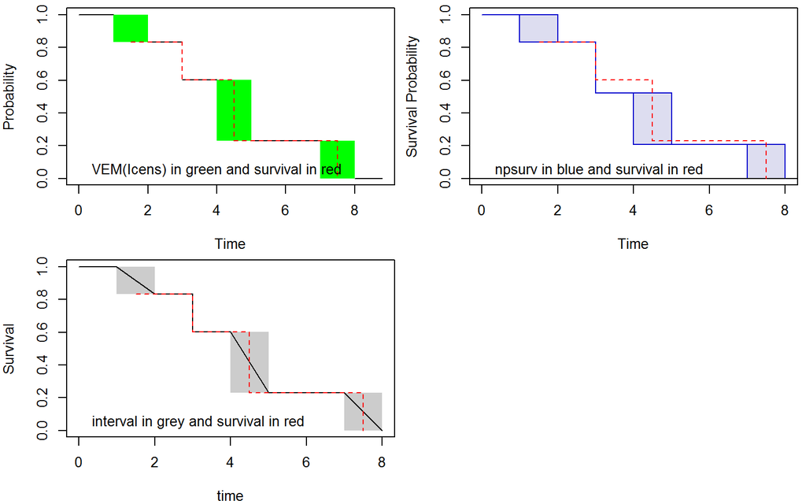

We can see that the constrained Newton method (CNM) implemented in the npsurv package gives a different mass estimation than the other methods. Now let us look at the differences between algorithms on various data sets.

```r
d3 <- data.frame(left = c(-1.4, 1.18, -1.4, 2, -1.4, 0),
                 right = c(1, 1.18, 2, NA, 0, 2))
compareNPMLE(d3)
```

```
## [1] "mass.Icens.VEM"
## [1] 0.418 0.000 0.418 0.164
## [1] "mass.Icens.EM"
## [1] 0.41563 0.00207 0.41563 0.16667
## [1] "mass.Icens.PGM"
## [1] 4.17e-01 3.91e-08 4.17e-01 1.67e-01
## [1] "mass.Icens.EMICM"
## [1] 4.17e-01 2.09e-10 4.17e-01 1.67e-01
## [1] "mass.survival"
## [1] 0.41172 0.00989 0.41172 0.00000 0.00000
## [1] "mass.interval"
## [1] 0.41648 0.00038 0.41648 0.16667
## [1] "message of icfit concerning Kuhn-Tucker conditions"
## [1] "normal convergence"
## [1] "mass.npsurv"
## [1] 0.417 0.417 0.167
```

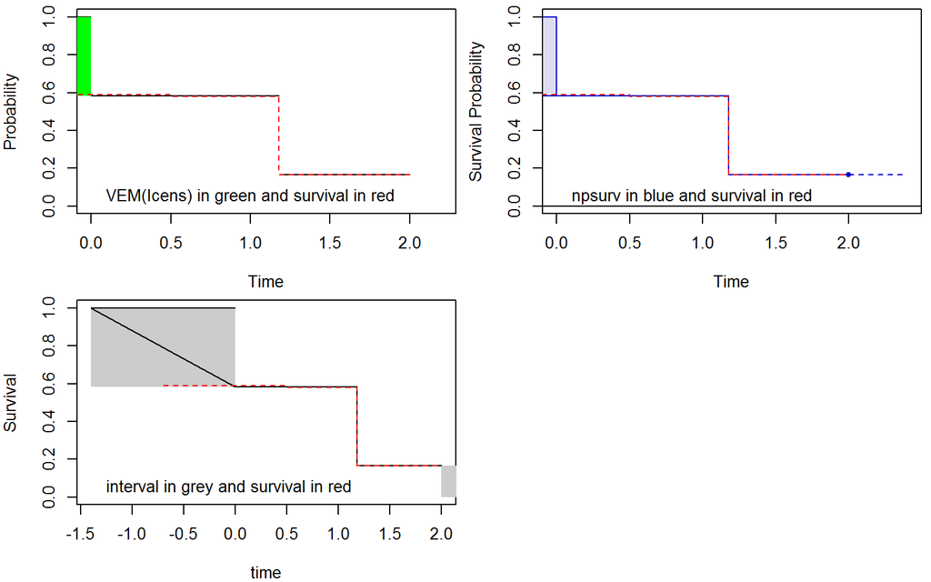

In this example we can see differences between the algorithms by the way they polish the ECDF function, by putting some masses to zero.

```r
data(bcos)
d6 <- subset(bcos, treatment == "Rad")[,1:2]
d6$right[is.infinite(d6$right)] <- NA
compareNPMLE(d6)
```

```
## [1] "mass.Icens.VEM"
##  [1] 0.0463 0.0334 0.0887 0.0708 0.0000 0.0000 0.0926 0.0000 0.0818 0.0000
## [11] 0.0000 0.1209 0.0000 0.4656
## [1] "mass.Icens.EM"
##  [1] 4.63e-02 3.34e-02 8.87e-02 7.08e-02 0.00e+00 0.00e+00 9.26e-02
##  [8] 0.00e+00 8.18e-02 0.00e+00 8.67e-13 1.21e-01 6.60e-12 4.66e-01
## [1] "mass.Icens.PGM"
##  [1] 0.0463 0.0334 0.0887 0.0708 0.0000 0.0000 0.0926 0.0000 0.0818 0.0000
## [11] 0.0000 0.1209 0.0000 0.4656
## [1] "mass.Icens.EMICM"
##  [1] 0.0463 0.0334 0.0887 0.0708 0.0000 0.0000 0.0926 0.0000 0.0818 0.0000
## [11] 0.0000 0.1209 0.0000 0.4656
## [1] "mass.survival"
##  [1] 4.63e-02 3.34e-02 8.86e-02 7.07e-02 0.00e+00 0.00e+00 0.00e+00
##  [8] 2.09e-05 0.00e+00 0.00e+00 0.00e+00 9.26e-02 8.15e-10 0.00e+00
## [15] 0.00e+00 8.18e-02 0.00e+00 5.52e-12 0.00e+00 4.77e-06 0.00e+00
## [22] 0.00e+00 1.21e-01 0.00e+00 3.19e-04 0.00e+00 0.00e+00 4.66e-01
## [1] "mass.interval"
## [1] 0.0463 0.0334 0.0887 0.0708 0.0926 0.0818 0.1209 0.4656
## [1] "message of icfit concerning Kuhn-Tucker conditions"
## [1] "normal convergence"
## [1] "mass.npsurv"
## [1] 0.0463 0.0334 0.0887 0.0708 0.0926 0.0818 0.1209 0.4656
```

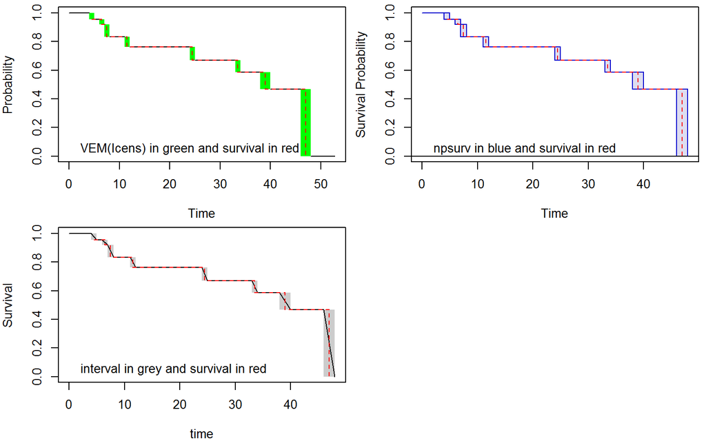

In this example,  
differences are small and not visible on the plots.

```r
data(salinity)
d7 <- log10(salinity)
compareNPMLE(d7)
```

```
## [1] "mass.Icens.VEM"
##  [1] 0.0405 0.0135 0.0143 0.0411 0.0229 0.0229 0.0235 0.0324 0.0580 0.0580
## [11] 0.0370 0.0370 0.0370 0.0370 0.0247 0.0805 0.0376 0.0802 0.0802 0.0554
## [21] 0.0831 0.0831
## [1] "mass.Icens.EM"
##  [1] 0.0405 0.0135 0.0143 0.0411 0.0229 0.0229 0.0235 0.0324 0.0580 0.0580
## [11] 0.0370 0.0370 0.0370 0.0370 0.0247 0.0805 0.0376 0.0802 0.0802 0.0554
## [21] 0.0831 0.0831
## [1] "mass.Icens.PGM"
##  [1] 0.0405 0.0135 0.0143 0.0411 0.0229 0.0229 0.0235 0.0324 0.0580 0.0580
## [11] 0.0370 0.0370 0.0370 0.0370 0.0247 0.0805 0.0376 0.0802 0.0802 0.0554
## [21] 0.0831 0.0831
## [1] "mass.Icens.EMICM"
##  [1] 0.0405 0.0135 0.0143 0.0411 0.0229 0.0229 0.0235 0.0324 0.0580 0.0580
## [11] 0.0370 0.0370 0.0370 0.0370 0.0247 0.0805 0.0376 0.0802 0.0802 0.0554
## [21] 0.0831 0.0831
## [1] "mass.survival"
##  [1] 0.00e+00 0.00e+00 0.00e+00 0.00e+00 2.25e-02 4.50e-02 1.04e-01
##  [8] 3.36e-02 0.00e+00 5.71e-02 5.71e-02 4.88e-07 0.00e+00 3.44e-02
## [15] 3.44e-02 6.88e-02 3.44e-02 1.15e-01 6.18e-02 6.18e-02 1.24e-01
## [22] 1.47e-01 4.56e-12
## [1] "mass.interval"
##  [1] 0.0225 0.0450 0.1039 0.0336 0.0571 0.0571 0.0344 0.0344 0.0688 0.0344
## [11] 0.1146 0.0618 0.0618 0.1236 0.1471
## [1] "message of icfit concerning Kuhn-Tucker conditions"
## [1] "normal convergence"
## [1] "mass.npsurv"
##  [1] 0.0180 0.0811 0.1313 0.0436 0.0436 0.0277 0.0277 0.0554 0.1555 0.0801
## [11] 0.0445 0.0445 0.1936 0.0534
```

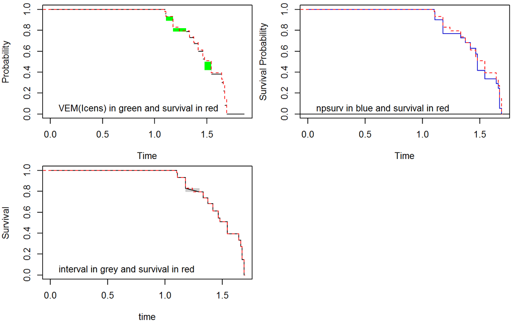

In this example, differences are stronger, and appear also between packages interval and Icens.

**I did not understand all about the check of the Kuhn-Tucker conditions (see Gentleman and Geyer) but I would like to ask Wang if this condition is checked in npsurv and if not if it is a problem.**

Using the npsurv package, I have implemented functions to plot the ECDF with rectangles. I could not use the plot function proposed in npsurv as it plots only positive values, considering the variable is a survival time, and dose not offer the possibility to plot an ECDF function instead of a survival function. Below is the new plot fucntion that could be included in the plotdistcens function of fitdistrplus.

```r
CDFplotcens <- function(d, plot = TRUE, add.Turnbull = TRUE)
# if add.Turnbull == TRUE add of the plot provided by survival
# output : vectors with Q and corresponding P values  for GOF stat
{
  db <- d
  db$left[is.na(db$left)] <- -Inf
  db$right[is.na(db$right)] <- Inf
  f <- npsurv(db)$f
  bounds <- c(f$right, f$left)
  finitebounds <- bounds[is.finite(bounds)]
  upper <- max(finitebounds)
  lower <- min(finitebounds)
  width <- upper - lower
  xlimup <- upper + width * 0.2
  xlimlow <- lower - width * 0.2
  xlimupinf <- upper + width * 100
  xlimlowinf <- lower - width * 100
  ## mettre la possibilité de rentrer des xlim et ylim par l'utilisateur bien sûr
  k <- length(f$left)
  Fnpsurv <- cumsum(f$p) # DONNER UN AUTRE NOM CAR RACCOURCI DE FALSE !!!!!!!!!!!!!!!!!!!!!!!!!!!!!!!!!

  ## calul des points points pour Q et P dnas les GOF stat et graph
  Fbefore <- c(0, Fnpsurv[-k])
  Fmid <- (Fbefore + Fnpsurv)/2
  df <- data.frame(left = f$left, right = f$right, Fmid = Fmid)
  # restriction to equivalence intervals without Inf
  dfb <- subset(df, (left != - Inf) & (right != Inf) )
  dfb$xmid <- (dfb$left + dfb$right) / 2

  if (plot)
  {
    ### tracé de la ligne à droite des zones indéterminées
    dright <- c(f$left[1], rep(f$right, rep(2,k)), f$right[k])
    Fright <- rep(c(0,Fnpsurv), rep(2,k+1))
    plot(dright, Fright, type = "l", xlim = c(xlimlow, xlimup), xlab = "x", ylab = "F")
    ### tracé de la ligne à gauche des zones indéterminées
    dleft = rep(c(f$left,f$right[k]), rep(2,k+1))
    Fleft = c(0,rep(Fnpsurv, rep(2,k)),1)
    lines(dleft, Fleft)
    ### Ajout des rectangles
    Fc <- c(0, Fnpsurv, 1)
    for(i in 1:k) {
      if(f$right[i] - f$left[i] > 0)
        rect(f$left[i], Fc[i], f$right[i], Fc[i+1], border = "black",
             col = "lightgrey")
    }
    abline(h = 0, lty = 2, col = "grey")
    abline(h = 1, lty = 2, col = "grey")
    # ajout des rectangles à droite et à gauche si besoin
    if(f$right[k] == Inf) rect(f$left[k], Fnpsurv[k - 1], xlimupinf, 1, border = "black",
                               col = "lightgrey")
    if(f$left[1] == - Inf) rect(xlimlowinf, Fnpsurv[1], f$right[1], 0, border = "black",
                                col = "lightgrey")

    #### Ajout des points qu'on prendrait en compte pour les GOF graph et stat
    points(dfb$xmid, dfb$Fmid, pch = 16, col = "blue")

    #### Ajout de l'ancienne présentation pour voir
    if (add.Turnbull)
    {
      (survdata <- Surv(time = d$left, time2 = d$right, type="interval2"))
      survfitted <- survfit(Surv(left, right, type="interval2") ~ 1, data = d)
      lines(survfitted$time, 1- survfitted$surv, type = "s", col = "red")
    }
  }
  return(list(Qi = dfb$xmid, Pi = dfb$Fmid))
}
```

Let us use test it on different data set including one (d2) with left censored values with which it was not possible to use icfit (icfit dosen not admit values at -Inf). The Turnbull plot provided by survival as added just compare it to the new representation.

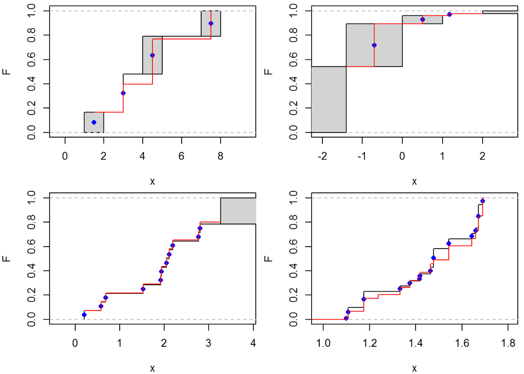

```r
data(smokedfish)
d2 <- as.data.frame(log10(smokedfish))
data(fluazinam)
d4 <- as.data.frame(log10(fluazinam))
par(mfrow = c(2,2))
par(mar = c(4, 4, 0.5, 0.5))
listd <- list(d1= d1, d2 = d2, d4 = d4, d7 = d7)
for (i in 1:length(listd))
{
  CDFplotcens(listd[[i]], add.Turnbull = TRUE)
}
```

At last, I have implemented, for the moment in a unique function, code that could be used in fitdistrplus in cdfcompcens and in new functions qqcompcens and ppcompcens.

```r
#### Function to plot GOF graphs from a fit on censored data ########################
#### It will certainly be difficult to plot more than one fit on the same plot ######
#### as it is proposed for non censored data ########################################
plotfitcens <- function(fti, CDFplot = TRUE, PPplot = TRUE, QQplot = TRUE, add.midpoints = TRUE)
  # output : vectors with Q and corresponding P values  for GOF stat
{
  d <- fti$censdata
  db <- d
  db$left[is.na(db$left)] <- -Inf
  db$right[is.na(db$right)] <- Inf
  f <- npsurv(db)$f
  bounds <- c(f$right, f$left)
  finitebounds <- bounds[is.finite(bounds)]
  upper <- max(finitebounds)
  lower <- min(finitebounds)
  width <- upper - lower
  xlimup <- upper + width * 0.2
  xlimlow <- lower - width * 0.2
  xmax <- xlimup # pour le plots ensuite
  xmin <- xlimlow
  xlimupinf <- upper + width * 100
  xlimlowinf <- lower - width * 100
  ## mettre la possibilité de rentrer des xlim et ylim par l'utilisateur bien sûr
  k <- length(f$left)
  Fnpsurv <- cumsum(f$p)

  ## calul des points points pour Q et P dans les GOF stat et graph
  Fbefore <- c(0, Fnpsurv[-k])
  Fmid <- (Fbefore + Fnpsurv)/2
  df <- data.frame(left = f$left, right = f$right, Fmid = Fmid)
  dfb <- subset(df, (left != - Inf) & (right != Inf) ) # without Inf
  dfb$xmid <- (dfb$left + dfb$right) / 2

  Qi <- dfb$xmid # dim k if no Inf, k-1 or k-2
  Pi <-  dfb$Fmid

  # Definition of vertices of each rectangle
  Qi.left <- df$left # dim k
  Qi.left4plot <- Qi.left
  if (Qi.left4plot[1] == - Inf) Qi.left4plot[1] <- xlimlowinf
  Qi.right <- df$right
  Qi.right4plot <- Qi.right
  if (Qi.right4plot[k] == Inf) Qi.right4plot[k] <- xlimupinf
  Pi.low <- Fbefore
  Pi.up <- Fnpsurv

  # recuperation des parametres ajustees et du nom de la distribution ajustee
  para <- c(as.list(fti$estimate), as.list(fti$fix.arg))
  distname <- fti$distname
  pdistname <- paste("p", distname, sep="")
  qdistname <- paste("q", distname, sep="")

  if (CDFplot)
  {
    plot(0, 0, type = "n", xlim = c(xlimlow, xlimup), ylim = c(0,1), xlab = "x", ylab = "F")
    for(i in 1:k) {
        rect(xleft = Qi.left4plot, ybottom = Pi.low, xright = Qi.right4plot, ytop = Pi.up,
             border = "black", col = "lightgrey")
    }
    abline(h = 0, lty = 2, col = "grey")
    abline(h = 1, lty = 2, col = "grey")

    ### Add of the two lines (only one is need if the rectangles are plotted)
    # the one at right
    dright <- c(f$left[1], rep(f$right, rep(2,k)), f$right[k])
    Fright <- rep(c(0,Fnpsurv), rep(2,k+1))
    lines(dright, Fright, type = "l", xlim = c(xlimlow, xlimup), xlab = "x", ylab = "F")
    ### the one at left
    dleft = rep(c(f$left,f$right[k]), rep(2,k+1))
    Fleft = c(0,rep(Fnpsurv, rep(2,k)),1)
    lines(dleft, Fleft)

    #### Add of the mid points
    if (add.midpoints) points(Qi, Pi, pch = 16, col = "black")

    ### Ajout de la courbe théo ajustée
    sfin <- seq(xmin, xmax, by=(xmax-xmin)/100)
    theopfin <- do.call(pdistname, c(list(q=sfin), as.list(para)))
    lines(sfin, theopfin, col = "red")
  } ############################# END CDFplot

  if (PPplot)
  {
    plot(0, 0, type = "n", main = "PPplot", xlim = c(0,1), ylim = c(0, 1))

    # plot of rectangles
    Pitheo.low <- do.call(pdistname, c(list(q=Qi.left), as.list(para)))
    Pitheo.up <- do.call(pdistname, c(list(q=Qi.right), as.list(para)))
    rect(xleft = Pitheo.low, ybottom = Pi.low, xright = Pitheo.up, ytop = Pi.up,
           border = "black", col = "lightgrey")
    abline(0,1)

    # add of mid moints
    if (add.midpoints)
    {
      Pitheo <- do.call(pdistname, c(list(q = Qi), as.list(para)))
      points(Pitheo, Pi, pch = 16, col = "black")
    }
  } ############# END of PPplot

  if (QQplot)
  {
    plot(0, 0, type = "n", main = "QQplot", xlim = c(xmin, xmax), ylim = c(xmin, xmax))

    # plot of rectangles
    Qitheo.left <- do.call(qdistname, c(list(p = Pi.low), as.list(para)))
    Qitheo.right <- do.call(qdistname, c(list(p = Pi.up), as.list(para)))
    Qitheo.left4plot <- Qitheo.left
    if (Qitheo.left4plot[1] == - Inf) Qitheo.left4plot[1] <- xlimlowinf
    Qitheo.right4plot <- Qitheo.right
    if (Qitheo.right4plot[k] == Inf) Qitheo.right4plot[k] <- xlimupinf
    rect(xleft = Qitheo.left4plot, ybottom = Qi.left4plot, xright = Qitheo.right4plot, ytop = Qi.right4plot,
           border = "black", col = "lightgrey")
    abline(0,1)


    # add of mid moints
    if (add.midpoints)
    {
      Qitheo <- do.call(qdistname, c(list(p = Pi), as.list(para)))
      points(Qitheo, Qi, pch = 16, col = "black")
    }
  }
}
```

Look at those new plots on fits of a normal distribution on different data sets.

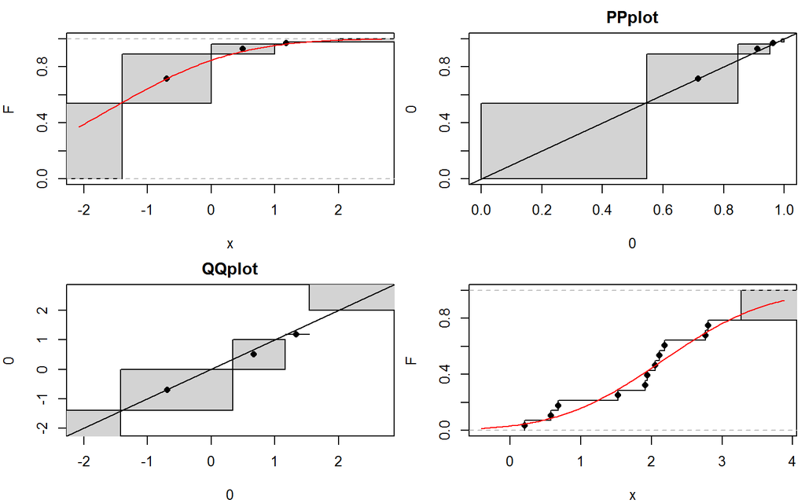

```r
d <- d2
f <- fitdistcens(d, "norm")
par(mfrow = c(2,2))
par(mar = c(4,4,2, 0.5))
plotfitcens(f)

d <- d4
f <- fitdistcens(d, "norm")
plotfitcens(f)
```

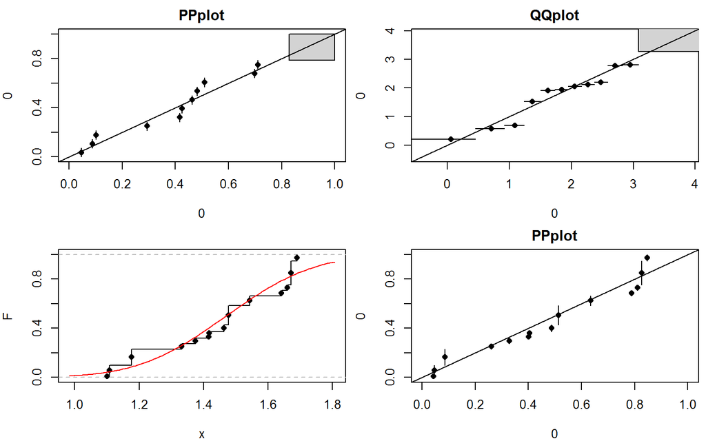

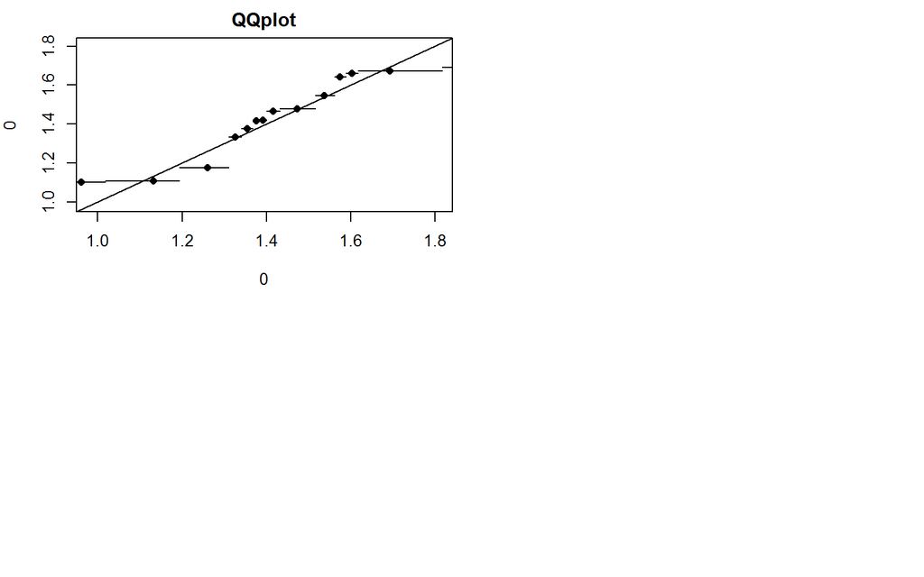

```r
d <- d7
f <- fitdistcens(d, "norm")
plotfitcens(f)
```

The last tested data set is a non censored data set on which we can compare plots to those provided using cdfcomp, ppcomp and qqcomp

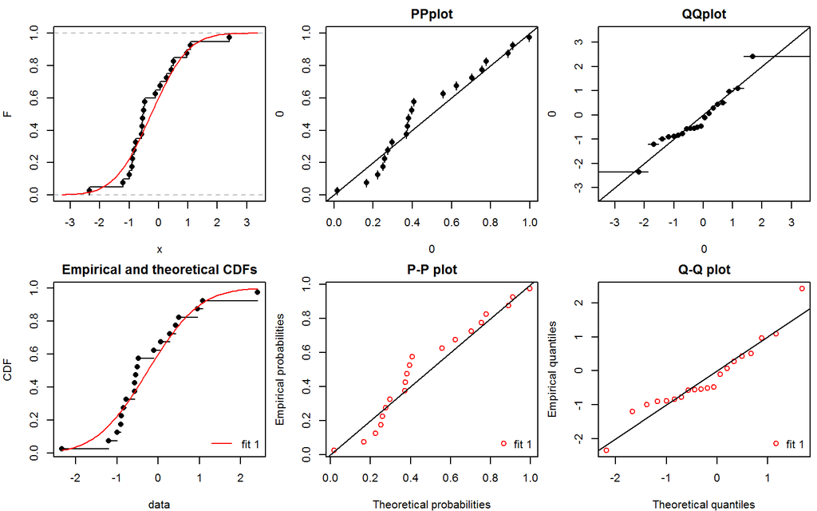

```r
set.seed(1234)
r <- rnorm(20)
d5 <- data.frame(left = r, right = r)
d <- d5
par(mfrow = c(2, 3))
par(mar = c(4,4,2, 0.5))
f <- fitdistcens(d, "norm")
plotfitcens(f)

fbis <- fitdist(d$left, "norm")
cdfcomp(fbis)
ppcomp(fbis)
qqcomp(fbis)
```